# Atac-seq

```r
b = barres[barres$Gene.symbol %in% var.genes,]
b = b[order(b$Specificity,decreasing = T),]
b[1:30,]
```

|  | Gene.symbol | Description | Astrocytes | Neuron | Oligodendrocyte.Precursor.Cell | Newly.Formed.Oligodendrocyte | Myelinating.Oligodendrocytes | Microglia | Endothelial.Cells | Specificity |
| --- | --- | --- | --- | --- | --- | --- | --- | --- | --- | --- |
| 7208 | Fezf2 | FEZ family zinc finger 2 | 2.6 | 1.5 | 0.4 | 0.1 | 0.2 | 0.2 | 0.1 | 2.500000 |
| 2793 | Asns | Asparagine synthetase | 1.2 | 17.4 | 17.4 | 10.3 | 4.5 | 2.0 | 6.6 | 2.485714 |
| 569 | 2310001H17Rik |  | 0.1 | 1.2 | 0.2 | 0.1 | 0.1 | 0.7 | 1.7 | 2.482759 |
| 2938 | Atp8a2 | ATPase, aminophospholipid transporter-like, class I, type 8A, member 2 | 0.1 | 6.2 | 2.6 | 1.4 | 0.8 | 9.9 | 0.2 | 2.480000 |
| 6603 | Erc1 | ELKS/RAB6-interacting/CAST family member 1 | 5.3 | 8.1 | 3.9 | 3.1 | 1.2 | 0.5 | 5.6 | 2.479592 |
| 7452 | Fst | Follistatin | 1.2 | 0.7 | 0.1 | 0.1 | 0.1 | 0.1 | 0.1 | 2.470588 |
| 17264 | Robo3 | Roundabout, axon guidance receptor, homolog 3 (Drosophila) | 0.1 | 0.7 | 0.2 | 0.1 | 0.2 | 1.0 | 0.1 | 2.470588 |
| 16514 | Ptprf | Protein tyrosine phosphatase, receptor type, F | 36.1 | 29.9 | 18.9 | 7.7 | 7.9 | 0.6 | 1.5 | 2.467675 |
| 15254 | Pcgf6 | Polycomb group ring finger 6 | 7.7 | 8.5 | 5.3 | 2.9 | 1.7 | 1.7 | 1.4 | 2.463768 |
| 2048 | AF529169 |  | 0.2 | 0.9 | 1.4 | 0.3 | 0.1 | 0.1 | 0.1 | 2.454545 |

[output cut: 20 more lines]

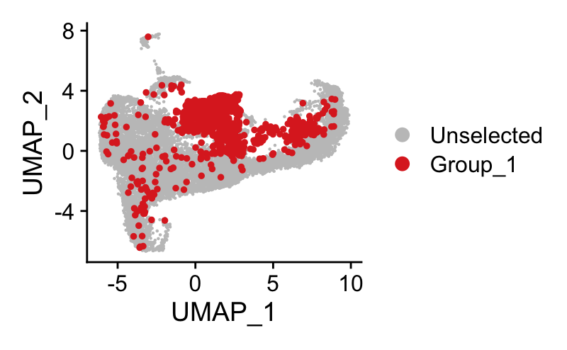

```r
DimPlot(sobject,cells.highlight = names(sobject$finalclusters)[sobject$finalclusters == '3'])
```

Save pcs and gene list for scvelo

```r
pcs = sobject@reductions$pca@cell.embeddings
pcs = cbind("Cellname" = rownames(pcs), pcs)
write.csv(pcs, file = "~/Desktop/Jupyter/mgAVM02/pcs_noneuronal.csv",row.names = F)
```

```r
genes = as.data.frame(VariableFeatures(sobject))
colnames(genes) = "Genes"
write.csv(genes, file = "~/Desktop/Jupyter/mgAVM02/genes_noneuronal.csv",row.names = F)
```

```r
load("/Users/whippoorwill/Desktop/Sequencing/LD_RNASeq2018/RData_v3/Current_LD1_march30.RData")
```

```r
sobject1 = mgAVM02
sobject2 = LD1
sobject2 = subset(sobject2,subset = celltype %in% c("opcs","oligos"))
column = "celltypecluster"
```

Add in a metadata column with celltypecluster

```r
meta1 = paste0("microglia_",sobject1$finalclusters)
names(meta1) = colnames(sobject1)
meta2 = sobject2$celltypecluster
meta1 = meta1[meta1 %in% c("microglia_4","microglia_5")]
meta = as.data.frame(c(meta1,meta2))
meta[,1] = as.character(meta[,1])
colnames(meta) = "Cluster"

#meta = cbind("Cellname" = rownames(meta),"Cluster" = meta[,1])
write.table(meta,file = "~/Desktop/Jupyter/OPC/meta.txt",sep = "\t",row.names = T,quote = F)
```

Make a counts file with both opcs and microglia

```r
countsm = GetAssayData(sobject1,slot = "counts")
countso = GetAssayData(sobject2,slot = "counts")

o = rownames(countso)
m = rownames(countsm)

length(o)
```

```
[1] 14645
```

```r
o =  o[o %in% m]
length(o)
```

```
[1] 14174
```

```r
m = m[m %in% o]
length(m)
```

```
[1] 14174
```

```r
countsm = countsm[rownames(countsm) %in% m,colnames(countsm) %in% names(meta1)]
countso = countso[rownames(countso) %in% o,]

head(countsm[,1])
```

```
  Sox17  Mrpl15  Lypla1   Tcea1   Rgs20 Atp6v1h
      0       1       0       1       0       2
```

```r
head(countso[,1])
```

```
  Sox17  Mrpl15  Lypla1   Tcea1   Rgs20 Atp6v1h
      0       0       0       1       0       0
```

```r
countsm = countsm[order(rownames(countsm)),]
countso = countso[order(rownames(countso)),]
```

```r
if (!identical(rownames(countso),rownames(countsm))){print("fix gene order")}
if (identical(rownames(countso),rownames(countsm))){
  counts = cbind(countsm,countso)
  rownames(counts) = toupper(rownames(counts)) #convert to ensemble ids
  library(org.Hs.eg.db)
 #any spreadsheet with gene symbols or other identifiers
  ids=rownames(counts)
  fromKey="SYMBOL" #must match the ids - could also be ensembl ID
  toKey=c("ENSEMBL") #whatever annotation you want to add - find with keytypes(db)
  db=org.Hs.eg.db
  selRes<-AnnotationDbi::select(db,keys=ids,keytype=fromKey,columns=c(fromKey,toKey))

  ##this is really used to get particular keys of the keytype "ensembl" (or any other type)

  x=selRes[match(ids,selRes[,1]),1:2]
  identical(x$SYMBOL,rownames(counts))
  rownames(counts) = x$ENSEMBL
  ids = rownames(counts)
  keep = !is.na(ids)
  counts = counts[keep,]
  write.table(counts,file = "~/Desktop/Jupyter/OPC/counts.txt",sep = "\t", quote = F,row.names = T)
}
```

Cellphone db: also from jupyter, see python script for details. “X3.04” means from cluster 3 (source) to cluster 4 (target)

```r
cellphonedb = read.csv("../Spreadsheets/OPC_2significant_means.csv",stringsAsFactors = F,fill = T)
#cellphonedb = read.csv("https://github.com/lcdorman/scrnaseq/blob/master/significant_means.csv",stringsAsFactors = F)
colnames(cellphonedb)
```

```
 [1] "id_cp_interaction"       "interacting_pair"        "partner_a"
 [4] "partner_b"               "gene_a"                  "gene_b"
 [7] "secreted"                "receptor_a"              "receptor_b"
[10] "annotation_strategy"     "is_integrin"             "rank"
[13] "microglia_4.microglia_4" "microglia_4.microglia_5" "microglia_4.oligos_7"
[16] "microglia_4.opcs_2"      "microglia_4.opcs_9"      "microglia_5.microglia_4"
[19] "microglia_5.microglia_5" "microglia_5.oligos_7"    "microglia_5.opcs_2"
[22] "microglia_5.opcs_9"      "oligos_7.microglia_4"    "oligos_7.microglia_5"
[25] "oligos_7.oligos_7"       "oligos_7.opcs_2"         "oligos_7.opcs_9"
[28] "opcs_2.microglia_4"      "opcs_2.microglia_5"      "opcs_2.oligos_7"
[31] "opcs_2.opcs_2"           "opcs_2.opcs_9"           "opcs_9.microglia_4"
[34] "opcs_9.microglia_5"      "opcs_9.oligos_7"         "opcs_9.opcs_2"
[37] "opcs_9.opcs_9"
```

```r
x = grep("opcs",colnames(cellphonedb))
y = grep("oligos",colnames(cellphonedb))

cellphonedb = cellphonedb[,c(1:12,x,y)]
x = grep("microglia_4",colnames(cellphonedb))
y = grep("microglia_5",colnames(cellphonedb))

cellphonedb = cellphonedb[,c(1:12,x,y)]

cdb = cellphonedb
```

count per interaction, remove rows with nothing

```r
cdb = cellphonedb[,13:ncol(cellphonedb)]
cdb = cdb[rowSums(cdb,na.rm = T)>0,]
```

Replace NA with 0 and any number with 1 (count incidents)

```r
cdb[!is.na(cdb)] = 1
cdb[is.na(cdb)] = 0
cd = colSums(cdb,na.rm = T)
cd
```

```
  microglia_4.opcs_2   microglia_4.opcs_9   opcs_2.microglia_4
                  26                   29                   29
  opcs_9.microglia_4 microglia_4.oligos_7 oligos_7.microglia_4
                  30                   21                   24
  microglia_5.opcs_2   microglia_5.opcs_9   opcs_2.microglia_5
                  18                   19                   21
  opcs_9.microglia_5 microglia_5.oligos_7 oligos_7.microglia_5
                  22                   13                   19
```

**Make a table(*

First we will repeat the names for source and target and then rename source and target to the appropriate portions of the name itself.

```r
cd = rbind("Source" = names(cd),"Target" = names(cd),"interactions" = cd)
cd["Source",] = sapply(cd["Source",],function(x)paste0("Source_",strsplit(x,"\\.")[[1]][1]))
cd["Target",] = sapply(cd["Target",],function(x)strsplit(x,"\\.")[[1]][2]) #split on ".", take 2nd
#cd["Target",] =sapply(cd["Target",],function(x)paste0("Target_",strsplit(x,"")[[1]][2]))
cd["Target",] =sapply(cd["Target",],function(x)paste0("Target_",x))#remove "0"
```

Make a 3D table first, then iterate through each matrix and add the 3rd dimension (#interactions) to its appropriate position

```r
x = table(cd["Source",],cd["Target",],cd["interactions",])
dimnames(x)
```

```
[[1]]
[1] "Source_microglia_4" "Source_microglia_5" "Source_oligos_7"
[4] "Source_opcs_2"      "Source_opcs_9"

[[2]]
[1] "Target_microglia_4" "Target_microglia_5" "Target_oligos_7"
[4] "Target_opcs_2"      "Target_opcs_9"

[[3]]
[1] "13" "18" "19" "21" "22" "24" "26" "29" "30"
```

```r
dim(x)[3]
```

```
[1] 9
```

```r
a = x[,,1]
for (i in 1:dim(x)[3]){
  t = x[,,i]
  a[t == 1] = dimnames(x)[[3]][i]
}
```

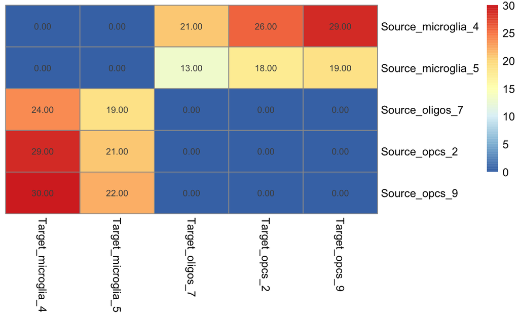

```r
library(pheatmap)

b = as.matrix.data.frame(a,rownames.force = T)
colnames(b) = colnames(a)
b = apply(b,MARGIN = c(1,2), function(x)as.numeric(x))

pheatmap(b, display_numbers = T,scale = "none",cluster_cols = F,cluster_rows = F )
setEPS()
postscript("heatmap_cellphonedb.eps")
```

```
postscript
         4
```

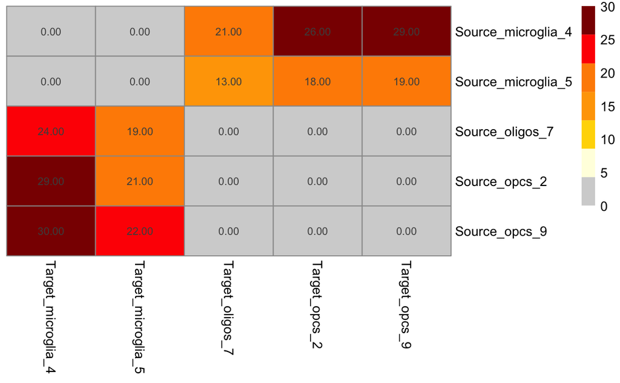

```r
pheatmap(b, display_numbers = T,scale = "none",cluster_cols = F,cluster_rows = F,color = c("lightgrey","lightyellow","gold","orange","darkorange","red","darkred" ))
dev.off()
```

```r
#expressed by opc-2 but not oligos, target mg 4 but not mg 5
cellphonedb[!is.na(cellphonedb$opcs_2.microglia_4) & is.na(cellphonedb$opcs_2.microglia_5),c("interacting_pair","secreted","opcs_2.microglia_4")]
```

|  | interacting_pair | secreted | opcs_2.microglia_4 |
| --- | --- | --- | --- |
| 20 | BMP7_SLAMF1 | TRUE | 0.273 |
| 35 | VCAM1_a4b1 complex | FALSE | 0.529 |
| 91 | TNFRSF1A_GRN | TRUE | 17.521 |
| 96 | JAM2_a4b1 complex | FALSE | 0.347 |
| 112 | FAM3C_CLEC2D | TRUE | 0.677 |
| 115 | MDK_PTPRZ1 | TRUE | 0.673 |
| 117 | LAMC1_aVb3 complex | TRUE | 0.232 |
| 135 | CADM3_CADM1 | FALSE | 1.275 |
| 138 | CADM1_CADM1 | FALSE | 1.632 |
| 139 | PTN_PTPRZ1 | TRUE | 8.425 |

```r
#

#expressed by opc-9 dividing but not oligos, target mg4 but not 5
cellphonedb[!is.na(cellphonedb$opcs_9.microglia_4) & is.na(cellphonedb$opcs_9.microglia_5),c("interacting_pair","secreted","opcs_9.microglia_4")]
```

|  | interacting_pair | secreted | opcs_9.microglia_4 |
| --- | --- | --- | --- |
| 20 | BMP7_SLAMF1 | TRUE | 0.375 |
| 35 | VCAM1_a4b1 complex | FALSE | 0.647 |
| 91 | TNFRSF1A_GRN | TRUE | 17.476 |
| 96 | JAM2_a4b1 complex | FALSE | 0.378 |
| 112 | FAM3C_CLEC2D | TRUE | 0.668 |
| 115 | MDK_PTPRZ1 | TRUE | 0.833 |
| 135 | CADM3_CADM1 | FALSE | 1.249 |
| 138 | CADM1_CADM1 | FALSE | 1.820 |
| 139 | PTN_PTPRZ1 | TRUE | 7.949 |

```r
#expressed by mg4 but not 5, target opc2
cellphonedb[!is.na(cellphonedb$microglia_4.opcs_2) & is.na(cellphonedb$microglia_5.opcs_2),c("interacting_pair","secreted","microglia_4.opcs_2")]
```

|  | interacting_pair | secreted | microglia_4.opcs_2 |
| --- | --- | --- | --- |
| 36 | ACVR_1B2A receptor_INHBB | TRUE | 0.122 |
| 37 | ACVR_1B2B receptor_INHBB | TRUE | 0.122 |
| 97 | IGF1_IGF1R | TRUE | 5.122 |
| 99 | LAMP1_FAM3C | TRUE | 23.388 |
| 102 | CCL3_IDE | TRUE | 2.675 |
| 103 | NRP1_VEGFB | TRUE | 3.446 |
| 109 | SIRPA_CD47 | FALSE | 8.542 |
| 138 | CADM1_CADM1 | FALSE | 1.632 |

```r
#expressed by mg4 but not 5, target opc9 dividing
cellphonedb[!is.na(cellphonedb$microglia_4.opcs_2) & is.na(cellphonedb$microglia_5.opcs_9),c("interacting_pair","secreted","microglia_4.opcs_9")]
```

|  | interacting_pair | secreted | microglia_4.opcs_9 |
| --- | --- | --- | --- |
| 36 | ACVR_1B2A receptor_INHBB | TRUE | 0.137 |
| 37 | ACVR_1B2B receptor_INHBB | TRUE | 0.137 |
| 97 | IGF1_IGF1R | TRUE | 5.152 |
| 99 | LAMP1_FAM3C | TRUE | 23.378 |
| 102 | CCL3_IDE | TRUE | 2.750 |
| 103 | NRP1_VEGFB | TRUE | 3.526 |
| 109 | SIRPA_CD47 | FALSE | 8.525 |
| 138 | CADM1_CADM1 | FALSE | 1.820 |

```r
NA
```